# ProsperLoan Data Analysis by Shireley

## 定稿图与总结

### 绘图一

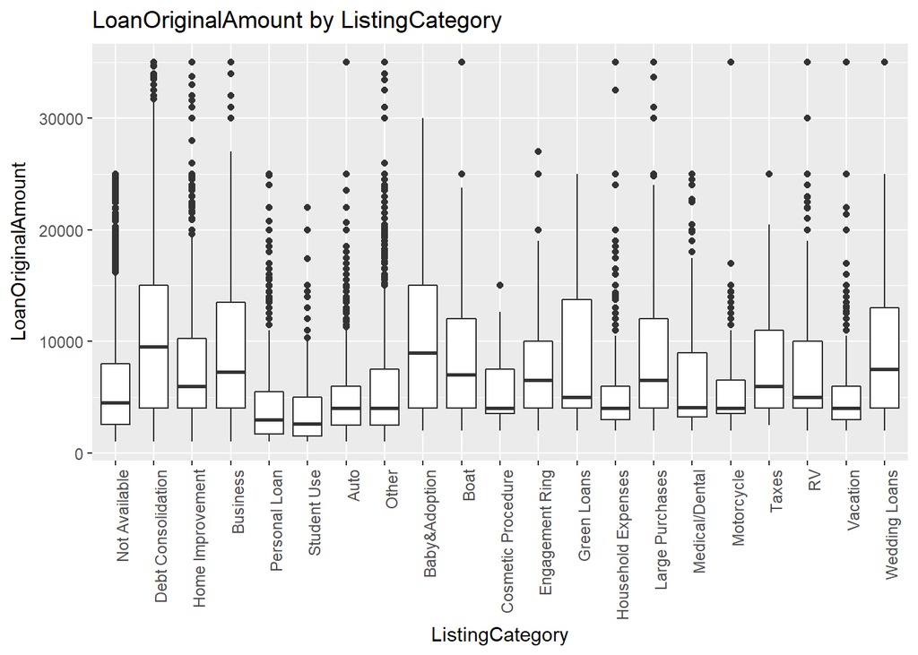

### 绘图二

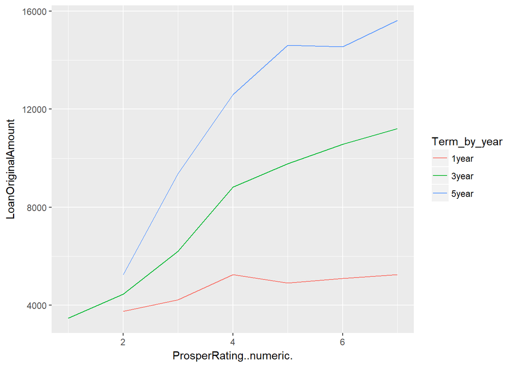

#### 描述二

1年期贷款均值<3年期贷款均值<5年期贷款均值，三者随着ProsperRating..numeric.增加而增加，但增加幅度不同，5年期增幅最大，3年期次之，1年期最小。

### 绘图三

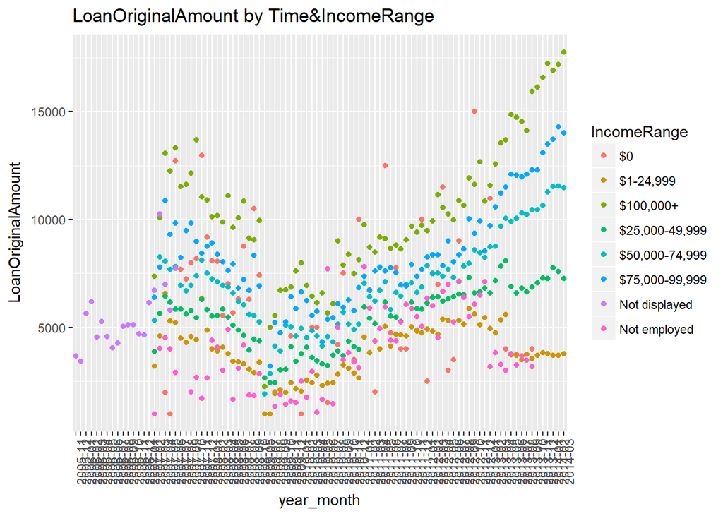

#### 描述三

不同IncomeRange所处的LoanOriginalAmount范围虽然不同，但是趋势大致相同，都经历了上涨-下跌-上涨的过程，除了$1-24,999范围在最后阶段处于下降趋势阶段，与其他范围趋势不同。

## 反思

1.项目初期对变量的选择比较盲目，受主观因素影响大。  
2.在数据探索过程中，有些变量之间的关系不明显，无法准确把握这些关系。思维不够开放，没有能够从多角度对数据进行深入分析。  
3.对ggplot代码不够熟悉，制作的图形不够美观精致。  
4.建立的线性回归模型较为简单，没有深入探索模型以达到优化模型的目的。  
5.在之后的分析中，可以对变量之间的correlation进行分析以验证两者之间的联系，同时，将对回归模型进一步探索来提高模型的准确度。